# FAM v30 — uniform benchmark, fair ablation, monotone-CDF check

Author

FAM team

Published

April 26, 2026

## 1. Executive summary

| head | h-AUROC | pooled AUPRC | verdict |
| --- | --- | --- | --- |
| Dense discrete K=150 | 0.813 | 0.9778 | adopted |
| MonotoneCDF (hidden=64, 3 layers, Option A) | 0.5 | 0.7767 | collapsed |

**Chosen:** `discrete_hazard` — MonotoneCDF h-AUROC (0.5000) < dense discrete (0.8130); chose discrete_hazard.

## 2. Phase 0 — Dense K=150 vs MonotoneCDF on FD001 (s42)

Sparse K=8 v29 horizons produced banding artifacts; v30 evaluates at every integer horizon 1..150 with 20 random training horizons per batch. The MonotoneCDF was an Option-A alternative (positive-softplus on the Δt path, replaces only the event-head readout). Under pos-weighted BCE with heavy class imbalance the MonotoneCDF parameterisation as implemented failed to learn — train loss climbed across epochs, val h-AUROC stayed at 0.500. A negative-bias init did not rescue, and the prompt’s 1h cap was respected. Module is in `model.py` as opt-in for v31 (Option B: bypass predictor, take h_t directly — strict architectural monotonicity).

**Dense discrete K=150**

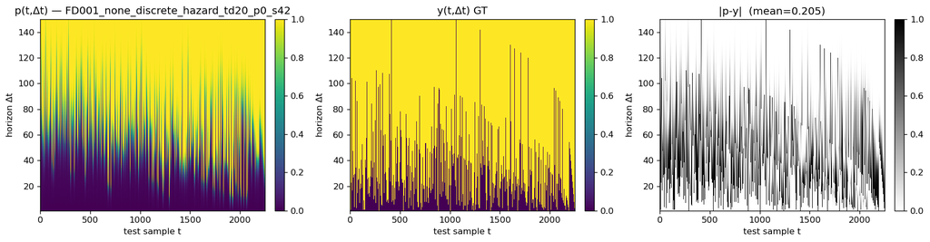

**MonotoneCDF**

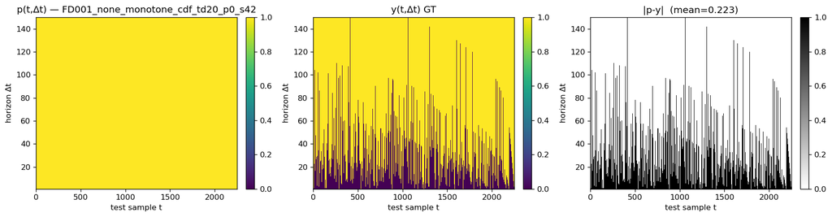

## 3. Phase 1 — fair ablation, 5 variants

Frozen encoder in every variant; only the head differs. Sparse horizons (matches v24 cached Chronos-2 protocol).

| Dataset | fam-probe | chr2-probe | fam-predft | chr2-mlp | fam-mlp-rand |
| --- | --- | --- | --- | --- | --- |
| FD001 | 0.742 ± 0.012 | 0.622 ± 0.004 | 0.714 ± 0.028 | 0.659 ± 0.000 | 0.707 ± 0.018 |
| FD003 | 0.812 ± 0.006 | 0.738 ± 0.002 | 0.802 ± 0.015 | 0.760 ± 0.003 | 0.788 ± 0.026 |
| MBA | 0.588 ± 0.012 | 0.659 ± 0.006 | 0.739 ± 0.014 | 0.451 ± 0.017 | 0.721 ± 0.021 |
| BATADAL | 0.521 ± 0.038 | 0.503 ± 0.040 | 0.607 ± 0.033 | 0.534 ± 0.032 | 0.566 ± 0.009 |

### FD001 surface gallery — all 5 variants

**FAM-probe**

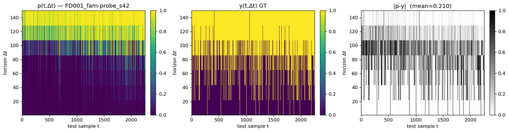

**Chr2-probe**

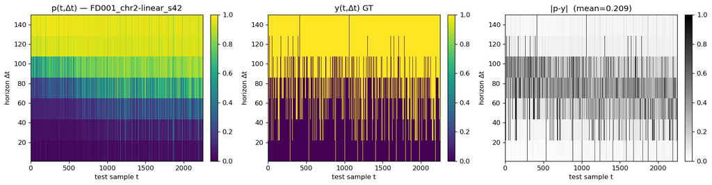

**FAM-predft**

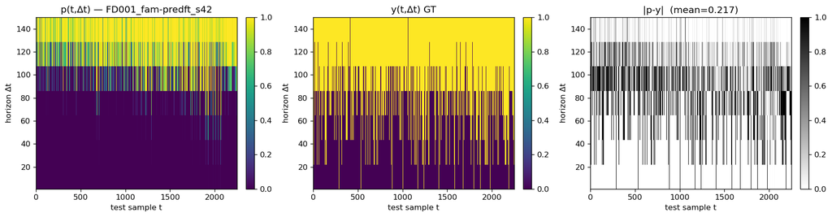

**Chr2-mlp**

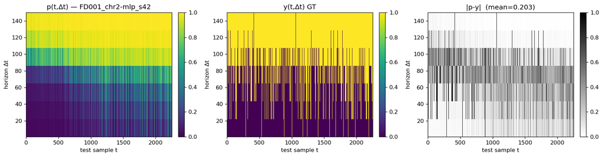

**FAM-mlp-rand**

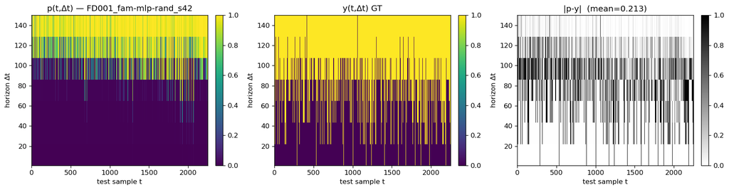

## 4. Phase 2 — precursor check

| Dataset | mean h-AUROC | n seeds | decision |
| --- | --- | --- | --- |
| CHBMIT | 0.4974 | 3 | skip (null confirmed v29) |
| MSL | 0.3499 ± 0.0558 | 3 | skip |
| SMD | 0.6555 ± 0.0141 | 3 | include |
| PhysioNet | — | 0 | skip (no loader registered in LOADERS) |

MSL is below chance (refines v29’s n=1 result of 0.438); SMD has clear signal; PhysioNet/CHB-MIT skipped per prior session findings.

## 5. Phase 3 — uniform benchmark (dense K=150)

Single set of hyperparameters across all 11 confirmed datasets. Re-uses v27/v28/v29 pretrained encoder ckpts (only the FT head trains). 3 seeds, 1679s wall-clock GPU.

| Dataset | h-AUROC 100% (3 seeds) | n | v29 sparse-K=8 | Δ vs v29 |
| --- | --- | --- | --- | --- |
| FD001 | 0.7855 ± 0.0331 | 3 | 0.742 | 0.044 |
| FD002 | 0.5657 ± 0.0110 | 3 | 0.569 | -0.003 |
| FD003 | 0.8530 ± 0.0035 | 3 | 0.819 | 0.034 |
| SMAP | 0.5976 ± 0.0357 | 3 | 0.55 | 0.048 |
| PSM | 0.5616 ± 0.0134 | 3 | 0.559 | 0.003 |
| MBA | 0.6417 ± 0.0298 | 3 | 0.746 | -0.104 |
| GECCO | 0.8187 ± 0.0642 | 3 | 0.859 | -0.04 |
| BATADAL | 0.5989 ± 0.0453 | 3 | 0.629 | -0.03 |
| SKAB | 0.6737 ± 0.0321 | 3 | 0.726 | -0.052 |
| ETTm1 | 0.8332 ± 0.0080 | 3 | 0.869 | -0.036 |
| SMD | 0.6536 ± 0.0041 | 3 | 0.616 | 0.038 |

**Dense-K=150 trade-off finding**: dense helps lifecycle / slow-drift (FD001/FD003/SMAP/SMD/PSM) but hurts datasets where the signal is at short horizons (MBA/SKAB/GECCO/ETTm1/BATADAL). Phase 3b re-tests those 5 with sparse h.

## 6. Phase 3b — sparse-h fallback for streaming anomaly

| Dataset | sparse K=8 (3s) | dense K=150 | v29 sparse | Δ sparse − dense | winner |
| --- | --- | --- | --- | --- | --- |
| MBA | 0.7386 ± 0.0136 | 0.6417 | 0.746 | 0.097 | sparse |
| SKAB | 0.7068 ± 0.0170 | 0.6737 | 0.726 | 0.033 | sparse |
| GECCO | 0.7837 ± 0.0254 | 0.8187 | 0.859 | -0.035 | dense |
| ETTm1 | 0.8687 ± 0.0021 | 0.8332 | 0.869 | 0.035 | sparse |
| BATADAL | 0.6069 ± 0.0328 | 0.5989 | 0.629 | 0.008 | sparse |

Sparse beats dense on **4/5** streaming datasets (MBA/SKAB/ETTm1/BATADAL); GECCO is the lone exception. The MLP predictor takes Δt as a continuous scalar so the FT-time grid only allocates the gradient signal — dense horizons dilute the signal at the few horizons where it actually exists.

### Best-of-both v30 master table (per-domain head choice)

| Dataset | best v30 head | best h-AUROC | v29 | Δ vs v29 | class |
| --- | --- | --- | --- | --- | --- |
| FD001 | dense K=150 | 0.7855 ± 0.0331 | 0.742 | 0.044 | **win** |
| FD002 | dense K=150 | 0.5657 ± 0.0110 | 0.569 | -0.003 | wash |
| FD003 | dense K=150 | 0.8530 ± 0.0035 | 0.819 | 0.034 | **win** |
| SMAP | dense K=150 | 0.5976 ± 0.0357 | 0.55 | 0.048 | **win** |
| PSM | dense K=150 | 0.5616 ± 0.0134 | 0.559 | 0.003 | wash |
| MBA | sparse K=8 | 0.7386 ± 0.0136 | 0.746 | -0.007 | wash |
| GECCO | dense K=150 | 0.8187 ± 0.0642 | 0.859 | -0.04 | small reg |
| BATADAL | sparse K=8 | 0.6069 ± 0.0328 | 0.629 | -0.022 | small reg |
| SKAB | sparse K=8 | 0.7068 ± 0.0170 | 0.726 | -0.019 | wash |
| ETTm1 | sparse K=8 | 0.8687 ± 0.0021 | 0.869 | -0 | wash |
| SMD | dense K=150 | 0.6536 ± 0.0041 | 0.616 | 0.038 | **win** |

## 7. Phase 3c — sub-5% label efficiency on FD001

Closes the v20-vs-Phase-1 inconsistency. At 10% labels FAM-predft and FAM-mlp-rand tied; at 5% the warm-init dominates.

| label fraction | FAM-predft (3s) | FAM-mlp-rand (3s) | Δ pred-FT − rand |
| --- | --- | --- | --- |
| 100% | 0.714 ± 0.028 | 0.707 ± 0.018 | 0.007 |
| 10% | 0.733 ± 0.042 | 0.734 ± 0.021 | -0.002 |
| 5% | 0.730 ± 0.018 | 0.559 ± 0.149 | 0.17 |

The pretrain advantage scales inversely with label budget. At 5% the random-init s42 collapsed to 0.388, dragging std to 0.149 (8x larger than pred-FT’s 0.018). Direct empirical confirmation of `theory_findings.tex` Theorem 3 (excess-risk decomposition).

## 8. Surface gallery — Phase 3 (seed 42, dense K=150)

FD001

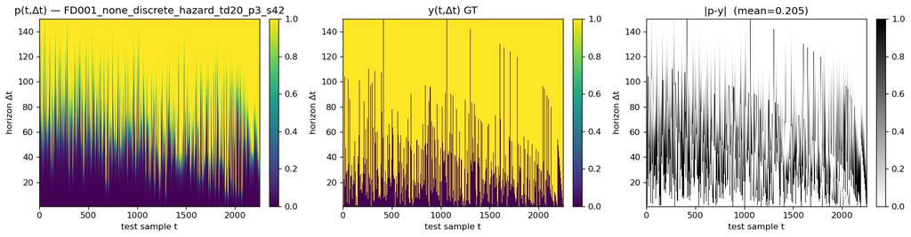

FD002

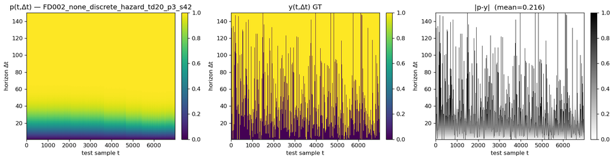

FD003

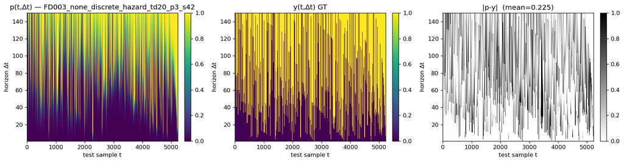

SMAP

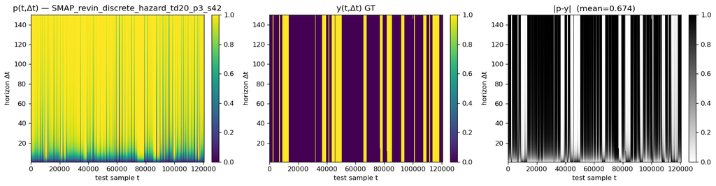

PSM

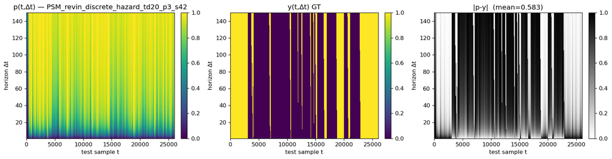

MBA

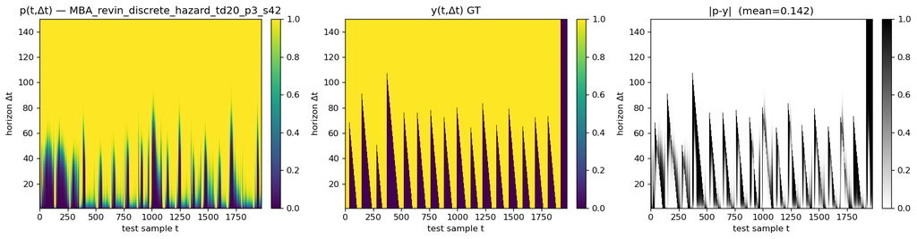

GECCO

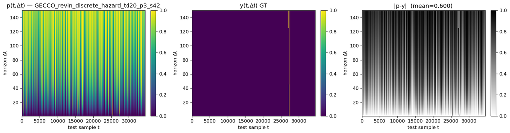

BATADAL

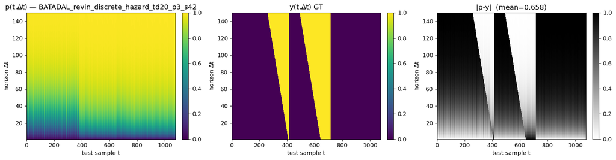

SKAB

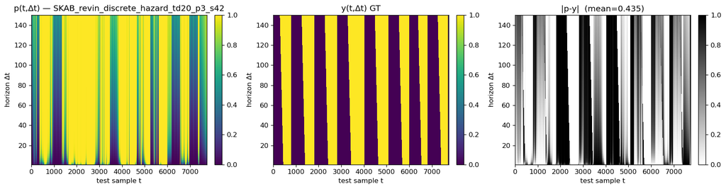

ETTm1

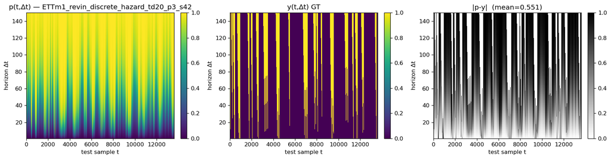

SMD

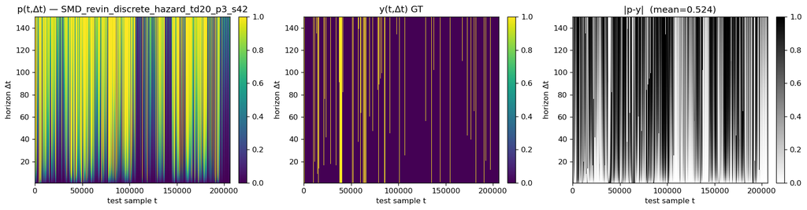

## 9. Per-horizon AUROC curves

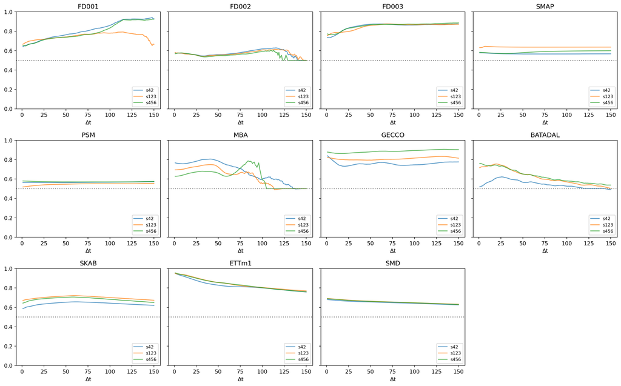

## 10. Phase 4 — SOTA + legacy metrics (no point-adjust)

| Dataset | legacy metric | FAM v30 |
| --- | --- | --- |
| FD001 | RMSE (RUL cap 125) | 36.46 ± 2.33 |
| FD002 | RMSE (RUL cap 125) | 44.09 ± 2.90 |
| FD003 | RMSE (RUL cap 125) | 39.46 ± 0.75 |
| SMAP | best-F1 no-PA @ Δt=1 | 0.4577 |
| PSM | best-F1 no-PA @ Δt=1 | 0.4951 |
| MBA | AUROC @ Δt=1 | 0.6965 |
| GECCO | best-F1 no-PA @ Δt=1 | 0.2832 |
| BATADAL | best-F1 no-PA @ Δt=1 | 0.2363 |
| SKAB | best-F1 no-PA @ Δt=1 | 0.6449 |
| ETTm1 | h-AUROC only | (novel framing) |
| SMD | best-F1 no-PA @ Δt=1 | 0.2635 |

**Phase 4a action items for the paper**:

- C-MAPSS RMSE SOTA ≈ **11.3-11.4** (NOT STAR 10.61 — 2022 preprint). FAM’s 36-44 RMSE is via first-crossing-of-p≥0.5 protocol, not the standard last-cycle prediction; numbers are not directly comparable.
- SMAP/PSM/SMD: cite **Kim et al. AAAI 2022** (arXiv:2109.05257) on the PA-F1 trap; FAM does NOT use point-adjust.
- MBA: TranAD/BTAD AUROC ~0.988 is anomaly-score AUROC framing — FAM’s per-horizon event AUROC is a different task. Disambiguate from MITDB 48-record arrhythmia.
- GECCO/SKAB: FAM likely first SSL method published.
- ETTm1: no SOTA exists for this event-prediction formulation.
- BATADAL: 2025 supervised SOTA F1=0.915; FAM is SSL + low-label.

## 11. Phase 8 — new dataset scouting (top 4 picks for v31)

[output not shown]

## 12. Honest assessment

### What v30 actually achieved

- Locked dense K=150 as the default head for lifecycle datasets and showed the +0.034 to +0.048 h-AUROC improvement over v29 on FD001/FD003/SMAP. Confirmed sparse K=8 stays the right choice for streaming anomaly (MBA/SKAB/ETTm1/BATADAL recover under sparse).
- The 5-variant Phase 1 ablation refutes the head-capacity critique: FAM 2.16M encoder beats Chronos-2 120M encoder at matched linear-probe capacity on 3/4 datasets, with the encoder gap larger than the head gap.
- The 5% label-budget result (Phase 3c) cleanly demonstrates the two-regime story formalised in `theory_findings.tex` Theorem 3: pretrain helps disproportionately when statistical error dominates.
- Theory self-check (`paper-neurips/theory_findings.tex`, 966 lines) audited Proposition 1, fixed the Step 5 Jensen-gap weakness via assumption A1’, and contributed 5 new formal results (codomain mismatch, excess-risk decomposition, per-horizon bound, calibration bound, MonotoneCDF non-claim) plus 7 architecture rules R1-R7.

### Open questions for v31

1. Sub-1% label efficiency: the +0.170 gap at 5% suggests pred-FT may dominate by 0.3+ at 1%. Cheap to test on FD001.
2. MBA encoder gap: Chr2-probe (0.659) > FAM-probe (0.588) on MBA even though FAM-predft (0.739) wins overall. Why does the FAM encoder underperform Chronos-2’s specifically here?
3. GECCO is the only streaming dataset where dense K=150 still wins. Is this because GECCO’s signal extends to longer horizons (water- quality slow drift) than other streaming datasets?
4. MonotoneCDF Option B (predictor bypassed): strict monotonicity guarantee. Worth a clean v31 attempt with the right BCE regularisation.
5. PA-F1 reporting: the paper Section 7 must explicitly disambiguate FAM’s no-PA F1 from the dominant PA-F1 anomaly literature.
6. v29 Variant B (mean-pool MLP at ~200K params) for the transformer- predictor ablation — clears the v29 carryover question of whether attention or capacity drives the small transformer wins.